## Homework Assignment 12

### Preliminaries

- Directories
  - COURSE/homework/
  - COURSE/homework/hw12/
  - COURSE/data/
  - COURSE/scripts/
- Files
  - COURSE/homework/hw12/hw12.Rmd
  - COURSE/data/lake-monona-winters-2022.csv
  - COURSE/scripts/viridis.R
  - COURSE/scripts/ggprob.R

### Data

The data set `lake-monona-winters-2022.csv` contains the date in which Lake Monona first freezes for each winter from 1855–1856 through 2021–2022. After transformations in the next code block, the variable `year1` is the first year of each winter and the variable `y` encodes the first freeze date as the number of days after June 30, so a value $y = 1$ is July 1, $y = 32$ is August 1, and $y = 185$ is January 1 of the following year.

### Aims

- Practice regression inference

## Problems

### 1

Fit a linear model to predict the value of $y$ (the date where Lake Monona first freezes measured in days after June 30) as a function of the first year of the winter, `year1`.

- Report the coefficients of this linear model.

#### Solution

```r
fit = lm(y ~ year1, data = monona)
coef(fit)
```

```
## (Intercept)       year1
## 22.44175333  0.07587063
```

### 2

- Use the **modelr** functions `add_residuals()` and `add_predictions()` to add columns for the residuals and predictions to the fitted model.
- Make a plot of the residuals versus the first year of winter.
  - Add a horizontal line with y-intercept zero.
- Comment on patterns in the residual plot which may or may not suggest either non-linearity or non-constant variance

#### Solution

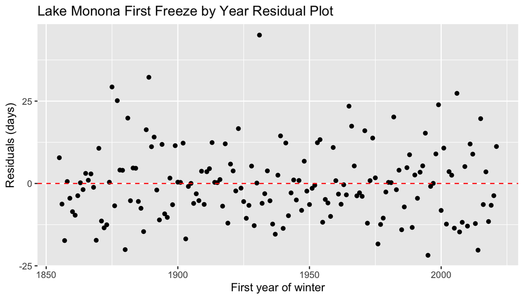

```r
monona = monona %>%
  add_residuals(fit) %>%
  add_predictions(fit)

ggplot(monona, aes(x = year1, y = resid)) +
  geom_point() +
  geom_hline(yintercept = 0, color = "red", linetype = "dashed") +
  xlab("First year of winter") +
  ylab("Residuals (days)") +
  ggtitle("Lake Monona First Freeze by Year Residual Plot")
```

> The residual plot provides no reason to suggest strong non-linearity nor unequal variances. There is no up-down pattern in the residuals and the size of residuals does not depend on the year.

### 3

- Create a 95% confidence interval for the slope parameter. (The interval is calculated as $\text{(Estimate)} \pm t^*\text{(SE)}$ where $t^*$ is an appropriate critical quantile from a t distribution with $n-2$ degrees of freedom in the case of simple linear regression.)
- Interpret the confidence interval in context.

You may use `summary()` to print the linear model summary. Alternatively, the following function returns the standard errors from the fitted linear model object as a base R vector.

```r
## example usage
## model = lm(y ~ x)
## se = lm_se(model)
##
lm_se = function(model)
{
  return ( sqrt(diag(vcov(model))) )
}
```

#### Solution

```r
summary(fit)
```

```
##
## Call:
## lm(formula = y ~ year1, data = monona)
##
## Residuals:
##     Min      1Q  Median      3Q     Max
## -21.804  -6.830  -0.880   4.969  45.052
##
## Coefficients:
##             Estimate Std. Error t value Pr(>|t|)
## (Intercept) 22.44175   34.55283   0.649    0.517
## year1        0.07587    0.01782   4.257 3.47e-05 ***
## ---
## Signif. codes:  0 '***' 0.001 '**' 0.01 '*' 0.05 '.' 0.1 ' ' 1
##
## Residual standard error: 11.1 on 165 degrees of freedom
## Multiple R-squared:  0.09895,    Adjusted R-squared:  0.09349
## F-statistic: 18.12 on 1 and 165 DF,  p-value: 3.471e-05
```

```r
slope = coef(fit)[2]
slope
```

```
##      year1
## 0.07587063
```

```r
se = lm_se(fit)[2]
se
```

```
##     year1
## 0.0178236
```

```r
n = nrow(monona)
n
```

```
## [1] 167
```

```r
ci = slope + c(-1,1)*qt(0.975, n-2) *se

round(ci,3)
```

```
## [1] 0.041 0.111
```

### 4

- Assume that a linear model between the first freeze date (coded as #days after June 30) and first year of winter is appropriate for the Lake Monona data and that you can interpret this model as a feature of the climate in Madison over time for the past 160+ years.
- Examine code below which creates a 95% confidence interval for the expected date for Lake Monona to first freeze in the winter of 2022-2023. *(Note: the fitted regression line is an estimate of the location of this hypothetical feature of climate change over time.)*
- Interpret the confidence interval in context (use actual dates rather than coded days after June 30).
- Make a scatter plot of the coded first freeze date versus year and add the plot of a regression line with a ribbon using `geom_smooth()`.
- Explain what feature of the ribbon corresponds to the confidence interval you calculated.

```r
## confidence interval using predict()
new_data = tibble(
  year1 = 2022
)

predict(monona_lm, new_data, interval = "confidence") %>%
  round(digits = 1)
```

```
##     fit   lwr   upr
## 1 175.9 172.4 179.3
```

#### Solution

> We are 95% confident that the expected date for Lake Monona to first freeze during the 2022-2023 winter is between December 19 and December 26.

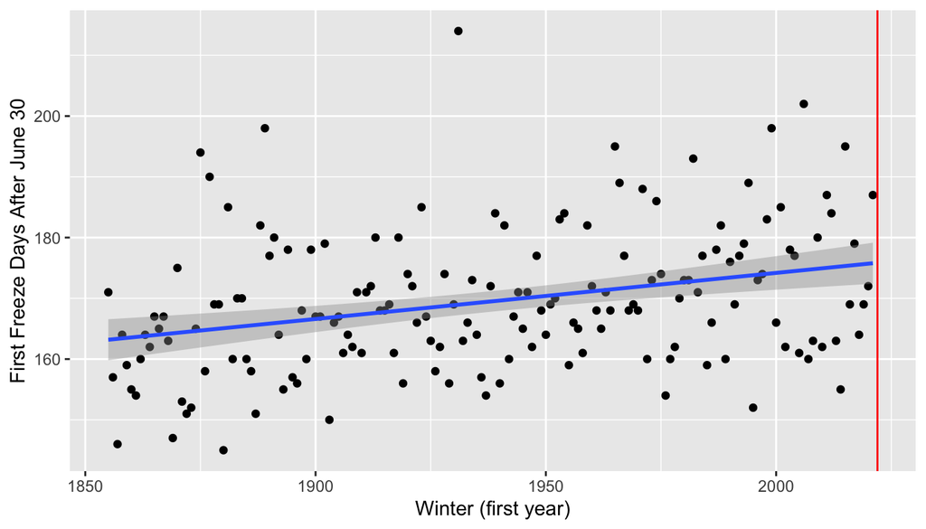

```r
ggplot(monona, aes(x = year1, y = y)) +
  geom_point() +
  geom_smooth(method = "lm") +
  geom_vline(xintercept = 2022, color = "red") +
  xlab("Winter (first year)") +
  ylab("First Freeze Days After June 30")
```

### 5

- The following block of code uses a fitted linear model to create a 95% prediction interval for the individual date in the 2022-2023 winter when Lake Monona will first freeze.
- Interpret the interval in context (use dates and not numerical values).
- Explain what feature of the provided plot corresponds to this prediction interval.

```r
predict(monona_lm, new_data, interval = "prediction") %>%
  round(digits = 1)
```

```
##     fit   lwr upr
## 1 175.9 153.7 198
```

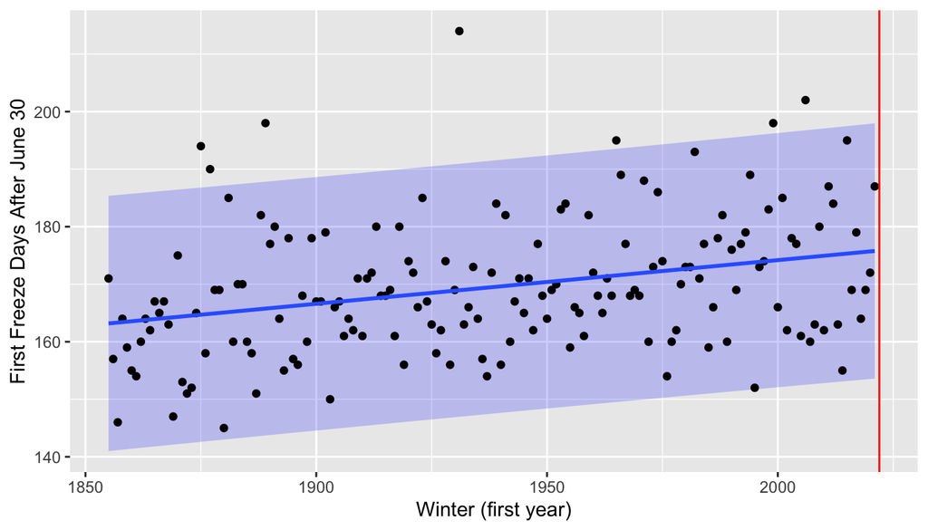

```r
full_prediction = predict(monona_lm, monona,
                          interval = "prediction") %>%
  as_tibble()

monona = monona %>%
  mutate(pred_lwr = full_prediction$lwr,
         pred_upr = full_prediction$upr)

ggplot(monona, aes(x = year1, y = y)) +
  geom_ribbon(aes(ymin = pred_lwr, ymax = pred_upr),
              alpha = 0.2, fill = "blue") +
  geom_point() +
  geom_smooth(method = "lm", se = FALSE) +
  geom_vline(xintercept = 2022, color = "red") +
  xlab("Winter (first year)") +
  ylab("First Freeze Days After June 30")
```

#### Solution

> There is a 95% probability that the Lake Monona will freeze for the first time this winter between December 1 and January 14.

> The prediction interval is the slice of the ribbon at $x = 2022$.

> Note: The prediction interval is more sensitive to the normal distribution assumption than the confidence interval approach is. The residual distribution appears it may be skewed a bit right and our symmetric normal approach may underestimate the probability missing for especially late freeze dates.

### 6

- What is the unit of measurement for $\hat{\sigma}$?

> [Response]

Assume that a linear model between `y` (date of the first freeze after June 30) and `year1` (first year of the winter) is appropriate for another 100 years.

- Without making a calculation, using the 167 years of data from the winter of 1855-56 through the winter of 2021-2022, will the width of the confidence interval for the expected first freeze date in the winter of 2100-2101 be wider than, the same width as, or narrower than the width you found in Problem 4? Briefly explain.

> [Response]

#### Solutions

> The parameter estimate $\hat{\sigma}$ is measured in days.

> The confidence interval will be wider as the explanatory variable $x = 2100$ is much further from the mean $\bar{x} = 1938$ than $x = 2022$ is. The formula for the SE of the confidence interval for $\mathsf{E}(\hat{y} \,\mid\, x = x^*)$ is:

$$\frac{\hat{\sigma}}{\sqrt{n}} \times
\sqrt{1 + \frac{(x^* - \bar{x})^2}{\sigma_x^2}}$$

> Keeping the data the same, the value of this SE increases as $(x^* - \bar{x})^2$ increases.

### 7

Assume that a linear model between `y` (date of the first freeze after June 30) and `year1` (first year of the winter) is appropriate for another 100 years and that we have data from the winter of 1855-56 through the winter of 2099-2100. Assume as well that the estimate of $\hat{\sigma}$ is unchanged after adding the additional 78 winters of data (so $n = 245$ in this hypothetical data set). We are interested in confidence and prediction intervals for the date of the first freeze when $x^* = 2100$.

- Will the confidence interval for the expected first freeze date in the winter of 2100-2101, $\mathsf{E}(\hat{y} \,\mid\, x^* = 2100)$, be wider than, the same width as, or narrower than the width you found in Problem 4? Briefly explain.

> [Response]
- Will the prediction interval for the first freeze date in the winter of 2100-2101 be wider than, the same width as, or narrower than the width you found in Problem 5? Briefly explain.

> [Response]

#### Solution

- As $n$ increases, the width of the confidence interval gets smaller. Here, we are also further from the mean $x$ value which causes the interval to get larger. We can make the calculations to see which factor prevails here.

```r
x_0 = 2100

old_x = 1855:2021
new_x = 1855:2099

old_n = length(old_x)
new_n = length(new_x)

old_mean_x = mean(old_x)
new_mean_x = mean(new_x)

old_sd_x = sd(old_x) * sqrt((old_n - 1)/old_n)
new_sd_x = sd(new_x) * sqrt((new_n - 1)/new_n)

sigma_hat = sigma(monona_lm)

old_se = sigma_hat/sqrt(old_n) * sqrt(1 + (2100 - old_mean_x)^2/old_sd_x^2)

new_se = sigma_hat/sqrt(new_n) * sqrt(1 + (2100 - new_mean_x)^2/new_sd_x^2)

old_se
```

```
## [1] 3.012558
```

```r
new_se
```

```
## [1] 1.423147
```

> The new SE is smaller as $n$ is larger.
- Prediction interval

> The prediction interval will also be narrower. The minimum width is $\hat{\sigma}$ at the mean of $x$ values. The larger distance from the mean is countered by the larger $n$. However, the width of the prediction interval does not change much as the SE is still just slightly larger than $\hat{\sigma}$.

> The formula for the SE of the prediction interval is

$$\hat{\sigma} \times
\sqrt{1 + \frac{(x^* - \bar{x})^2}{n\sigma_x^2}}$$

```r
## prediction
x_0 = 2100

old_se = sigma_hat * sqrt(1 + (2100 - old_mean_x)^2/(old_n*old_sd_x^2))

new_se = sigma_hat * sqrt(1 + (2100 - new_mean_x)^2/(new_n * new_sd_x^2))

old_se
```

```
## [1] 11.47309
```

```r
new_se
```

```
## [1] 11.17213
```

### 8

Briefly explain how the following violations of linear regression models might affect the validity of the confidence and prediction intervals from Problem 7.

- Non-linearity in the true relationship between first freeze date and year.

> [Response]
- A moderately skewed error distribution.

> [Response]

#### Solution

> Non-linearity would make both the confidence interval and prediction interval unreliable.

> Skewness will not affect much the confidence interval which is based on the sampling distribution of a mean, and the central limit theorem works in our favor.

> On the other hand, the validity of a prediction interval is strongly affected by non-normality in the true error distribution and this imprecision does not decrease with increased sample size.